# Homework 2 Report

## Name

Selah Norton

### Setup

Read in the data with `read_csv()` and store the data as an R object named `dataset`. Check the data to make sure all of the expected observations and variables are there.

```r
# Load necessary packages
library(tidyverse)
```

```r
library(ggplot2)
library(patchwork)
# Load the data
dataset <- read_csv('maacs.csv.gz')
# Check the data to ensure all expected observations and variables are there
head(dataset)
```

```
## # A tibble: 6 × 10
##   id         age gender  fev1   eNO cough_days  pm25   no2 mouse mouse_allergic
##   <chr>    <dbl> <chr>  <dbl> <dbl>      <dbl> <dbl> <dbl> <dbl> <chr>
## 1 fd171e2d  14.7 male    1.78   141          2  15.6  NA    2423 yes
## 2 a66fc33a  13.6 female  2.12    68          8  18.9  12.8   939 yes
## 3 fc038e68  14.5 male    2.73   210          2  17.8  NA     200 no
## 4 8e28b8c2  14.0 female  2.36    23          0  14.0  NA      NA no
## 5 b2699b54  16.6 female  3.13    18         14  17.9  31.0 10371 no
## 6 7d4f3508  16.6 female  2.59   128          0  43.8  10.6  4789 yes
```

## Part 1

We will first consider the relationship between FEV1 and age. In general, it is expected that as children get older (and hence, larger in size), their FEV1 values should get higher.

Consider the statement “FEV1 values in children are higher in older children relative to younger children”.

Write a function in R that takes the `dataset` object as an argument and returns `TRUE` if the statement above is true for the dataset and `FALSE` otherwise.

NOTE: In order to write this function, you will need to translate the statement above into something that can be checked with the data. There are many ways in which you can do that translation correctly and you only need to pick one way here.

NOTE: For this part, do not use any plots.

```r
## Write your function here
statement1 <- function(dataset){
  # Remove observations without fev1 values
  dataset <- dataset %>% drop_na(fev1)
  # Find median age to divide the two groups
  median_age <- median(dataset$age)
  dataset <- dataset %>%
    # Categorize ages into young or old
    mutate(age_group = ifelse(age<=median_age, "young", "old")) %>%
    group_by(age_group) %>%
    # Find mean fev1 value of each group
    summarize(avg_fev1 = mean(fev1))
  # If statement to see if the statement is true that values are higher in
  # older children
  if (dataset$avg_fev1[dataset$age_group == "old"] >
      dataset$avg_fev1[dataset$age_group == "young"]) {
    return(TRUE)
  } else {
    return(FALSE)
  }
}
statement1(dataset)
```

```
## [1] TRUE
```

## Part 2

Fit a linear regression model with FEV1 as the outcome and age as a predictor.

How much does FEV1 change for a 1-year increase in the child’s age?

```r
# Create linear regression model
model <- lm(fev1 ~ age, data=dataset)
# Extract coefficients
coef(model)
```

```
##  (Intercept)          age
## -0.001198833  0.171162271
```

The coefficient for the age predictor is 0.171. This means that the model predicts as the child age increases by one year, their FEV1 would also increase by 0.171 liters.

## Part 3

Develop **three** supporting premises derived from the data that support the statement you wrote in Part 2. These can be plots, other summary statistics, or model results.

NOTE:

- At least one supporting premise should use a plot.
- Do not use the code you write in Part 1 as a supporting premise

```r
# Remove observations without fev1 values
dataset <- dataset %>% drop_na(fev1)
# Find median age to divide the two groups
median_age <- median(dataset$age)
# Categorize ages into young or old
dataset_group <- dataset %>%
  mutate(age_group = ifelse(age<=median_age, "young", "old"))
```

## Part 4

For each of the supporting premises above, write a function that takes the `dataset` object as an argument and returns `TRUE` if the supporting premise statement above is true for the dataset and `FALSE` otherwise.

For statements involving plots, instead of returning `TRUE` or `FALSE`, you function should do two things:

1. Produce the plot that is used in the statement
2. Produce a hypothetical version of the plot in the event that the statement is true. This can be done using simulated data or by simply hand drawing a plot.

```r
## Function for supporting premise statement 1
supporting1 <- function(dataset) {
# Produce scatterplot in the statement
p1 <- dataset %>%
  ggplot(aes(x=age, y=fev1)) +
  geom_point() +
  # Set breaks, limits, labels to match on both graphs
  scale_x_continuous(
    breaks=c(0,8,12,16),
    name = 'Age') +
  scale_y_continuous(
    limits=c(0,5),
    name = 'FEV1 (liters)') +
  # Label plot
  labs(title = 'Actual Data')
# Set seed for consistency
set.seed(1221)
# Generate simulated data
x <- rnorm(150, 11, 2.5)
y <- 0.25*x - 2.5 + rnorm(150, mean = 2, sd = 0.3)
# Produce simulated plot in the statement
p2<- tibble(x = x, y = y) %>%
  ggplot(aes(x, y)) +
  geom_point() +
  scale_x_continuous(
    breaks=c(0,8,12,16),
    name = 'Age') +
  scale_y_continuous(
    limits=c(0,5),
    name = 'FEV1 (liters)') +
  # Label plot
  labs(title = 'Simulated Data')
# Combine plots to be directly compared
p1|p2
}
```

```r
## Function for supporting premise statement 2
supporting2 <- function(model){
  # Extract significance of age coefficient
  sig_age <- summary(model)$coefficients[1, "Pr(>|t|)"]
  # Set significance level and check to see if this meets that
  if (sig_age >= 0.95) {
    return(TRUE)
  } else {
    return(FALSE)
  }
}
```

```r
## Function for supporting premise statement 3
supporting3 <- function(dataset_group) {
# Produce box plot in the statement
p1 <- dataset_group %>%
  # Reorder x axis so lower fev1 group is on the left
  ggplot(aes(x=reorder(age_group, fev1), y=fev1)) +
  geom_boxplot() +
  # Label x and y axis
  scale_x_discrete(name='Age Group') +
  scale_y_continuous(name='FEV1 (liters)') +
  # Label plot
  labs(title = 'Actual Data')
# Set seed for consistency
set.seed(128)
# Generate simulated data
x <- rbinom(150, 1, 0.5)
y <- x -0.25 + rnorm(150, mean = 2, sd = 0.4)
# Produce simulated plot in the statement
p2<- tibble(x = x, y = y) %>%
  mutate(x = factor(x)) %>%
  ggplot(aes(x, y)) +
  geom_boxplot() +
  # Label x and y axis to match actual graph
  scale_x_discrete(name='Age Group',
                   labels= c('young', 'old')) +
  scale_y_continuous(name='FEV1 (liters)',
                     breaks= c(1,2,3,4,5),
                     limits = c(1,5)) +
  # Label plot
  labs(title = 'Simulated Data')
# Combine plots to be directly compared
p1|p2
}
```

Execute each of your function and show that the produce the expected output.

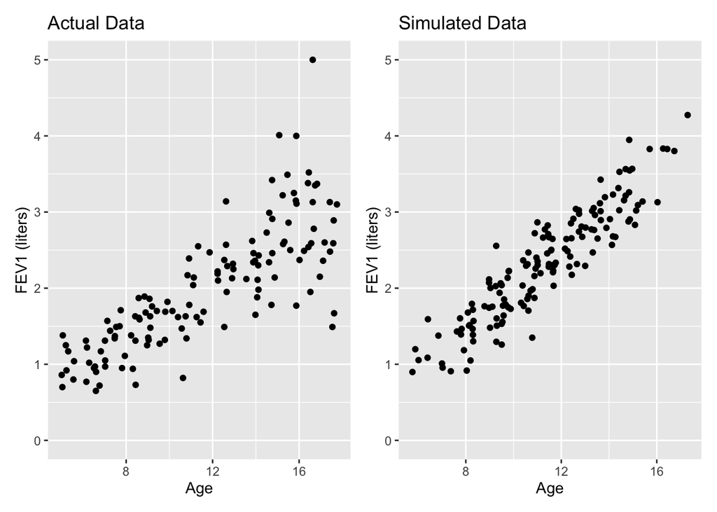

```r
supporting1(dataset)
```

```r
supporting2(model)
```

```
## [1] TRUE
```

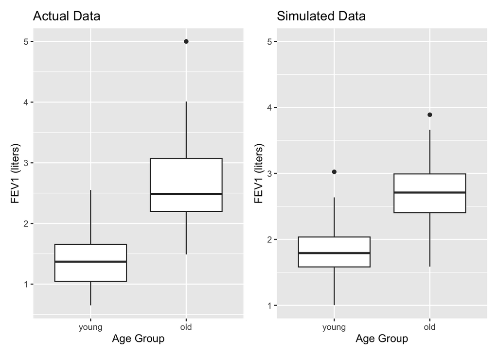

```r
supporting3(dataset_group)
```

## Part 5

Describe one alternative to the primary statement “FEV1 values in children are higher in older children relative to younger children”.

FEV1 values in children do not differ between younger and older children

Create a fault tree for the alternative outcome describing how the alternative outcome could be realized in the data even if the primary statement were true.

Your fault tree should be created as a separate image and does not need to be created in R. Upload the image of the fault tree to Canvas.